# RRD

Johnes

2024-10-15

```r
library(tidyverse)
library(rddensity)
library(rdrobust)
load("estratos_2y3_rdd.RData")
```

# Introducción

El propósito de este trabajo es estimar los efectos de la estratificación socioeconómica en la ciudad de Medellín, enfocándose específicamente en cómo dicha estratificación afecta el valor de las rentas y otros indicadores de calidad del hábitat en los diferentes barrios. La estratificación socioeconómica es una característica única del sistema colombiano, que asigna un estrato de 1 a 6 a las viviendas según el nivel socioeconómico del área en la que se encuentran, y es utilizado para definir subsidios y tarifas de servicios públicos. Este sistema, aunque útil en muchos casos, también puede tener efectos no deseados sobre los precios de la vivienda, la distribución de la riqueza y el acceso a servicios públicos y oportunidades de empleo en distintos sectores de la ciudad.

# Analisis exploratorio de los datos

```r
summary(estratos_2y3_rdd$valor_m2)
```

```
##     Min.  1st Qu.   Median     Mean  3rd Qu.     Max.
##     5220   450015   598890   764462   797218 10774862
```

El resumen estadístico de la variable `valor_m2` muestra una considerable dispersión en los valores de renta por metro cuadrado en los estratos 2 y 3 de Medellín. El valor mínimo es de 5,220, mientras que el valor máximo alcanza los 10,774,862, lo que refleja una gran variabilidad en los precios del suelo. El valor promedio (media) es de 764,462, mientras que la mediana, que representa el punto medio de los datos, es de 598,890, lo que sugiere que la distribución está sesgada hacia valores más altos, probablemente debido a algunos valores atípicos en el extremo superior. Además, el primer cuartil (450,015) y el tercer cuartil (797,218) indican que el 50% central de los valores se encuentra dentro de este rango.

```r
estratos_2y3_rdd %>%
  group_by(estrato) %>%
  summarise(
    Min = min(valor_m2, na.rm = TRUE),
    Q1 = quantile(valor_m2, 0.25, na.rm = TRUE),
    Median = median(valor_m2, na.rm = TRUE),
    Mean = mean(valor_m2, na.rm = TRUE),
    Q3 = quantile(valor_m2, 0.75, na.rm = TRUE),
    Max = max(valor_m2, na.rm = TRUE)
  )
```

```
## # A tibble: 2 × 7
##   estrato    Min      Q1  Median     Mean       Q3       Max
##   <fct>    <dbl>   <dbl>   <dbl>    <dbl>    <dbl>     <dbl>
## 1 2        5220. 408894. 495030.  508415.  598890.  5362617.
## 2 3       15419. 658780. 818916. 1129829. 1322208. 10774862.
```

El resumen estadístico para la variable `valor_m2` en los estratos 2 y 3 muestra diferencias notables. En el estrato 2, el valor mínimo es de 5,220 y el máximo llega a 5,362,617, con una mediana de 495,030 y una media de 508,414.7, lo que indica una distribución de precios más baja y relativamente menos dispersa. En contraste, el estrato 3 presenta valores más altos, con un mínimo de 15,419 y un máximo de 10,774,862. La mediana en el estrato 3 es de 818,916.3 y la media es considerablemente más alta, con 1,129,828.8, lo que sugiere una mayor variabilidad en los precios por metro cuadrado, probablemente debido a la presencia de valores atípicos hacia el extremo superior. Estos resultados reflejan una clara diferencia en los valores de renta por metro cuadrado entre ambos estratos, con los precios siendo considerablemente más altos en el estrato 3.

```r
estratos_2y3_rdd %>%
  group_by(estrato) %>%
  summarise(
    Min = min(viv_informal, na.rm = TRUE),
    Q1 = quantile(viv_informal, 0.25, na.rm = TRUE),
    Median = median(viv_informal, na.rm = TRUE),
    Mean = mean(viv_informal, na.rm = TRUE),
    Q3 = quantile(viv_informal, 0.75, na.rm = TRUE),
    Max = max(viv_informal, na.rm = TRUE)
  )
```

```
## # A tibble: 2 × 7
##   estrato   Min     Q1 Median   Mean     Q3   Max
##   <fct>   <dbl>  <dbl>  <dbl>  <dbl>  <dbl> <dbl>
## 1 2           0 0      0.0278 0.0698 0.0667     1
## 2 3           0 0.0102 0.0317 0.0527 0.0625     1
```

# Comprobación si es nitido

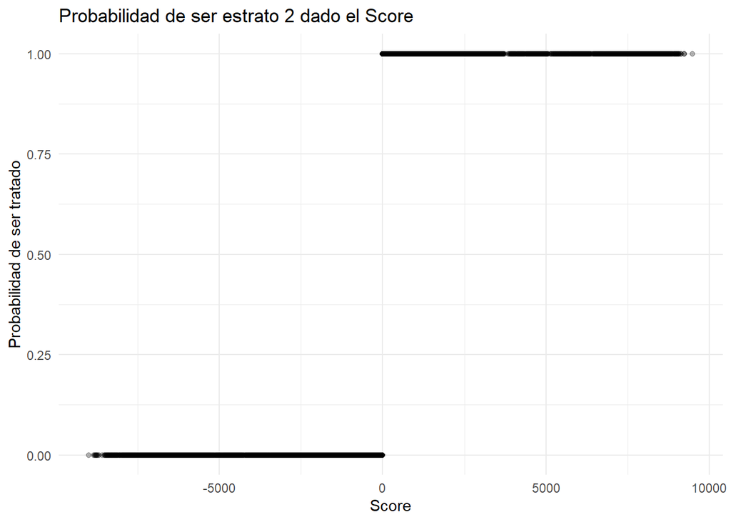

```r
ggplot(estratos_2y3_rdd, aes(x = score, y =treat )) +
  geom_point(alpha = 0.3) +
  labs(title = "Probabilidad de ser estrato 2 dado el Score",
       x = "Score", y = "Probabilidad de ser tratado") +
  theme_minimal()
```

El tipo de regresión discontinua es nitida dado que la probabilidad de recibir subsidio depende del score (distancia a la frontera), esta probabilidad cambia abruptamente cuando la distancia a la frontera es mayor o igual a cero, las manzanas son clasificadas como estrato 2 y reciben subsidio.

# test de MaCrary

```r
mccrary_test <- rddensity(estratos_2y3_rdd$score)
summary(mccrary_test)
```

```
##
## Manipulation testing using local polynomial density estimation.
##
## Number of obs =       8106
## Model =               unrestricted
## Kernel =              triangular
## BW method =           estimated
## VCE method =          jackknife
##
## c = 0                 Left of c           Right of c
## Number of obs         3318                4788
## Eff. Number of obs    550                 1380
## Order est. (p)        2                   2
## Order bias (q)        3                   3
## BW est. (h)           945.461             1267.751
##
## Method                T                   P > |T|
## Robust                -1.3321             0.1828
```

```
##
## P-values of binomial tests (H0: p=0.5).
##
## Window Length / 2          <c     >=c    P>|T|
## 8.293                      20      69    0.0000
## 16.585                     42      87    0.0001
## 24.878                     51      96    0.0003
## 33.170                     54     104    0.0001
## 41.463                     57     107    0.0001
## 49.755                     57     108    0.0001
## 58.048                     58     115    0.0000
## 66.341                     61     120    0.0000
## 74.633                     69     123    0.0001
## 82.926                     73     128    0.0001
```

El test arroja resultados basados en un análisis de discontinuidad alrededor de un punto de corte (c = 0). Se analizaron 8,106 observaciones, divididas en 3,318 a la izquierda del punto de corte y 4,788 a la derecha. El número efectivo de observaciones utilizadas para la estimación fue menor: 550 a la izquierda y 1,380 a la derecha, debido a la técnica de suavizado. El método aplicado fue un kernel triangular, y el ancho de banda estimado (h) fue de 945.461 y 1267.751 para cada lado del punto de corte.

# Efecto causal

```r
rd_result <- rdrobust(
    y = estratos_2y3_rdd$valor_m2,
    x = estratos_2y3_rdd$score
)

summary(rd_result)
```

```
## Sharp RD estimates using local polynomial regression.
##
## Number of Obs.                 8106
## BW type                       mserd
## Kernel                   Triangular
## VCE method                       NN
##
## Number of Obs.                 3318         4788
## Eff. Number of Obs.             365          660
## Order est. (p)                    1            1
## Order bias  (q)                   2            2
## BW est. (h)                 585.635      585.635
## BW bias (b)                1229.522     1229.522
## rho (h/b)                     0.476        0.476
## Unique Obs.                    3318         4743
##
## =============================================================================
##         Method     Coef. Std. Err.         z     P>|z|      [ 95% C.I. ]
## =============================================================================
##   Conventional-119964.830 14924.696    -8.038     0.000[-149216.697 , -90712.963]
##         Robust         -         -    -7.123     0.000[-144790.036 , -82302.271]
## =============================================================================
```

El coeficiente estimado indica la magnitud del cambio en el valor del metro cuadrado cuando se cruza el umbral entre los estratos. Si este coeficiente es negativo, sugiere que a medida que los hogares se acercan al estrato 2, el valor de la vivienda tiende a disminuir, lo que puede reflejar la percepción de menor calidad del hábitat en estratos más bajos o la presencia de desigualdades económicas en Medellín. La significancia estadística de los resultados, indicada por un valor p bajo, refuerza la idea de que la distancia a la frontera estratificada tiene un impacto real en el valor de la propiedad.

# Recomendación de política

Se recomienda implementar políticas económicas que incluyan inversiones en infraestructura y servicios públicos en los barrios de estrato 2 de Medellín, ya que el análisis revela un efecto negativo en el valor del metro cuadrado al cruzar el umbral entre los estratos. Estas políticas podrían incluir subsidios para la renovación de viviendas, desarrollo de espacios comunitarios, programas de capacitación laboral y incentivos fiscales para empresas que inviertan en la zona, con el objetivo de mejorar la calidad del hábitat, reducir desigualdades económicas y fomentar un desarrollo urbano más equitativo y sostenible.